# Lab 3 - Checkpoint 1: Análise de dados de buscas em projetos da Wikimedia - Inferência

O objetivo deste estudo é investigar dados de buscas realizadas por usuários em projetos da Wikimedia. Os dados de buscas de usuários selecionados aleatoriamente foram coletados durante 8 dias por logs de eventos e disponibilizados em processos seletivos da Wikimedia Foundation em 2016. Os dados originais estão disponiveis no site da wikimedia em ‘/data/search_data.csv.’ Os dados são usados para avaliar a satisfação do usuário com os resultados das buscas. Os resultados, armazenados em logs, permitem identificar o tempo que os usuários permanecem nas páginas visitadas.

Realizou-se em relatórios anteriores análise descritiva dos dados, nesse relatório será realizada inferência via intervalos de confiança, usando bootstrap. O objetivo é estimar com confiança de 95% intervalos para caracteristicas da população (todos os projetos).

## 1. Configurações iniciais e conjunto de dados

O primeiro passo para iniciarmos o estudo é conhecer a base de dados, as variáveis utilizadas e as configurações iniciais. O código a seguir mostra as bibliotecas e dependências utilizadas.

```r
library(tidyverse)
library(here)
library(lubridate)
```

```r
library(ggplot2)
library(knitr)
library(boot)
theme_set(theme_bw())
```

```r
buscas = read_csv(here::here("data/search_data.csv")) %>%
    mutate(day=round_date(session_start_date, unit = "day")) %>%
    filter((first_click <= results) | (is.na(first_click) & num_clicks == 0)) #%>%
    #head(10000)

## Parsed with column specification:
 cols(
   session_id = col_character(),
   search_index = col_integer(),
   session_start_timestamp = col_double(),
   session_end_timestamp = col_double(),
   session_start_date = col_datetime(format = ""),
   session_end_date = col_datetime(format = ""),
   checkin = col_integer(),
   group = col_character(),
   results = col_integer(),
   num_clicks = col_integer(),
   first_click = col_integer()
 )
```

No código acima temos as bibliotecas utilizadas e a leitura dos dados. Incluimos ainda a coluna **day** que contém a data, sem a hora, apenas o dia. O nosso conjunto de dados possui as seguintes colunas:

session_id: Essa coluna é um ID exclusivo que identifica as sessões; search_index: Index da busca realizada pelo usuário na sessão; session_start_timestamp: Marcação do tempo no início da busca; session_end_timestamp: Marcação do tempo no fim da busca; session_start_date: Data e hora do início da busca; session_end_date: Data e hora do fim da busca; checkin: Duranção do tempo em que a página ficou aberta; group: Representa o grupo. Esse grupo pode ser “a” ou “b”, sendo o grupo b, o grupo de controle; results: Número de resultados retornados ao usuário; num_clicks: Número de cliques do usuário; first_click: Posição do resultado que o usuário clicou primeiro.

Além de incluir a variável day, alguns dados foram filtrados e removidos da base inicial por serem considerados inconsistentes. COnsiderando a explicação da semântica de cada coluna, temos que o primeiro clique do usuário deve está entre 1 e o número total de resultados retornado pela busca. Sendo assim, o número first_click deve está entre 1 e results. Além disso, o número de cliques (num_clicks) deve está consistente com a coluna first_click. Se o usuário fez algum clique, deve existir a posição do primeiro click. Linhas que não atendem esses parâmetros foram consideradas inconsistentes e foram filtradas.

Iremos utilizar a técnica de bootstrap e intervalos de confiança para responder as questões a seguir:

## 2. Pergunta 1: Qual é a taxa de cliques geral diária? Como isso varia entre os grupos?

A primeira inferência realizada é sobre a média do número de cliques. Apesar da pergunta está relacionada com a taxa de cliques geral diária,inicialmente podemos concluir com 95% de confiança no método utilizado que a média de número de cliques está entre (0.2878, 0.2951), ou seja, a taxa de cliques é muito baixa. Isso ocorre porque na amostra temos muitas buscas com nenhum clique. Isso foi identificado em relatório anterior.

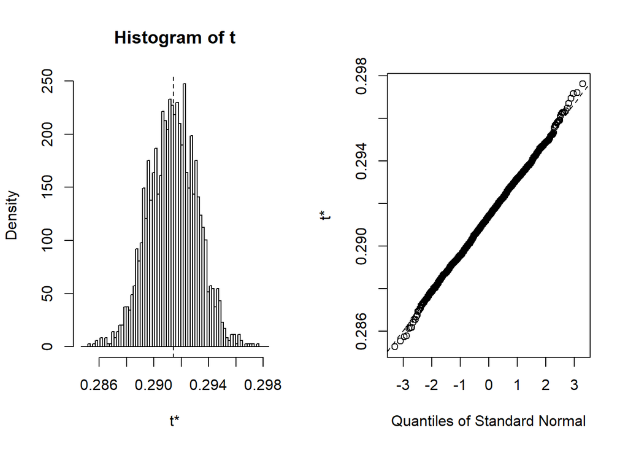

```r
fun.boot <- function(x, i) {
    mean(x[i])
}

#summary(buscas)

res.boot <- boot(data = buscas$num_clicks,
                 statistic = fun.boot,
                 R = 2000)
plot(res.boot)
```

```r
boot.ci(boot.out = res.boot, conf = 0.95, type = "basic")
```

```
## BOOTSTRAP CONFIDENCE INTERVAL CALCULATIONS
## Based on 2000 bootstrap replicates
##
## CALL :
## boot.ci(boot.out = res.boot, conf = 0.95, type = "basic")
##
## Intervals :
## Level      Basic
## 95%   ( 0.2881,  0.2949 )
## Calculations and Intervals on Original Scale
```

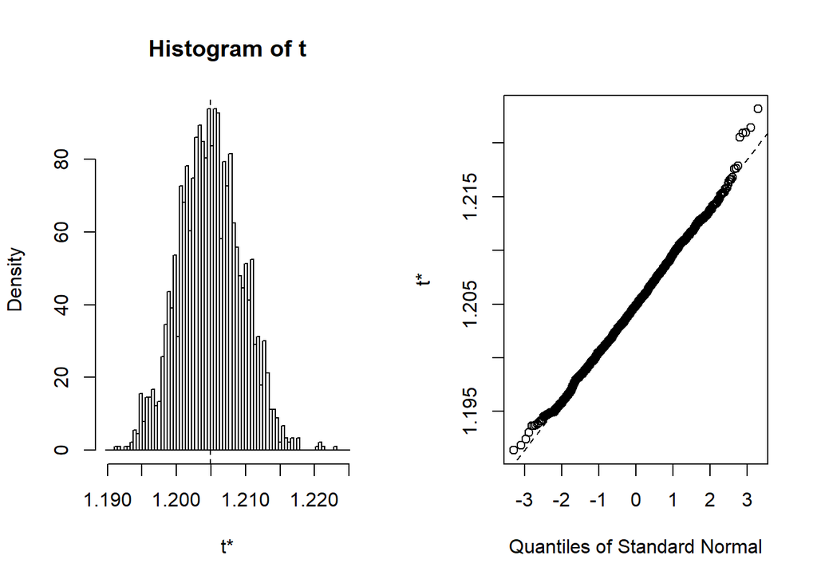

```r
buscasComClicks = buscas %>%
    filter((num_clicks > 0))

fun.boot <- function(x, i) {
    mean(x[i])
}

#summary(buscas)

res.boot <- boot(data = buscasComClicks$num_clicks,
                 statistic = fun.boot,
                 R = 2000)
plot(res.boot)
```

```r
boot.ci(boot.out = res.boot, conf = 0.95, type = "basic")
```

```
## BOOTSTRAP CONFIDENCE INTERVAL CALCULATIONS
## Based on 2000 bootstrap replicates
##
## CALL :
## boot.ci(boot.out = res.boot, conf = 0.95, type = "basic")
##
## Intervals :
## Level      Basic
## 95%   ( 1.196,  1.214 )
## Calculations and Intervals on Original Scale
```

COnsiderando que a taxa de cliques é a soma dos cliques do dia dividido pelo total de buscas naquele dia, o objetivo é estimar esse valor e verificar como varia entre os grupos A e B. A função sumariza o número de cliques e dividide pelo total de buscas no mesmo dia.

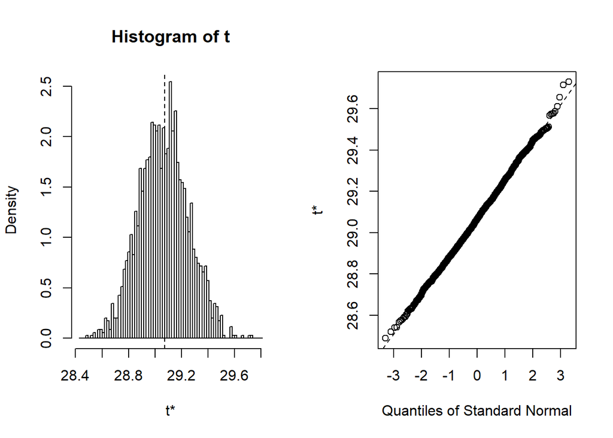

```r
amostra <- buscas

taxaCliques <- function(dados, indices) {
    media <- dados %>%
            slice(indices) %>%
            group_by(day) %>%
            summarise(clicks = sum(num_clicks), n = n(), taxa = (clicks/n)*100) %>%
            pull(taxa) %>%
            mean()
    return(media)
}

#summary(amostra)

res.boot <- boot(data = amostra,
                 statistic = taxaCliques,
                 R = 2000)

plot(res.boot)
```

```r
boot.ci(boot.out = res.boot, conf = 0.95, type = "basic")
```

```
## BOOTSTRAP CONFIDENCE INTERVAL CALCULATIONS
## Based on 2000 bootstrap replicates
##
## CALL :
## boot.ci(boot.out = res.boot, conf = 0.95, type = "basic")
##
## Intervals :
## Level      Basic
## 95%   (28.72, 29.43 )
## Calculations and Intervals on Original Scale
```

A partir do gráfico e dos resultados acima, podemos inferir que a média geral diária do número de cliques está entre 28,70% e 29,44% com 95% de confiança. Agora iremos analisar a taxa de cliques geral diária por grupos. A taxa diáriade cliques permanece sendo calculada da mesma forma, todavia é preciso agrupar por grupo. A partir do gráfico e dos resultados abaixo, podemos inferir que a diferença na média geral diária do número de cliques entre os grupos A e B, está entre 19,70 e 20,92 com 95% de confiança. Como não interceptou o eixo zero, podemos inferir que a taxa de cliques diária, para o grupo A, é sempre maior que a taxa de cliques para o grupo B.

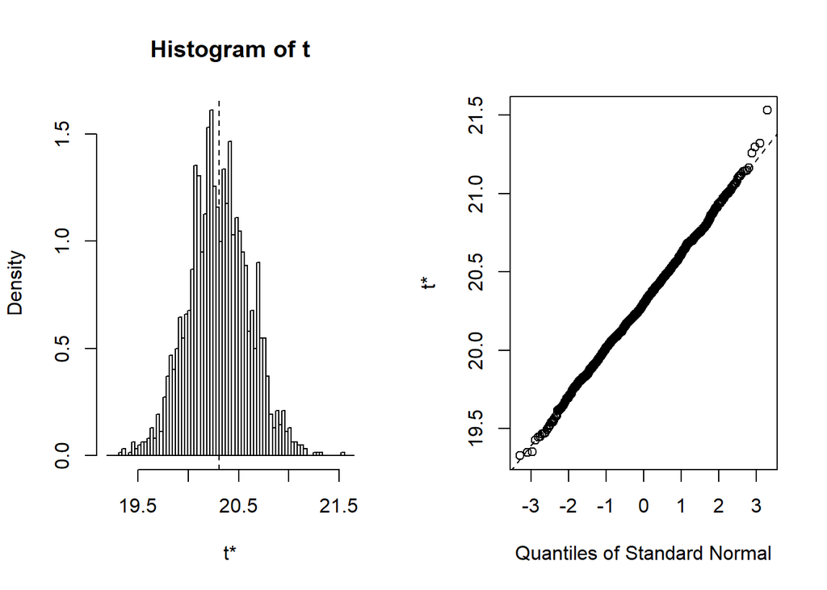

```r
amostra <- buscas

taxaCliques <- function(dados, indices) {
    mediaTC <- dados %>%
            slice(indices) %>%
            group_by(group, day) %>%
            summarise(clicks = sum(num_clicks), n = n(), taxa = (clicks/n)*100) %>%
            summarise(media = mean(taxa)) %>%
            pull(media)

    return(mediaTC[1] - mediaTC[2])
}

#summary(amostra)

res.boot <- boot(data = amostra,
                 statistic = taxaCliques,
                 R = 2000)
plot(res.boot)
```

```r
boot.ci(boot.out = res.boot, conf = 0.95, type = "basic")
```

```
## BOOTSTRAP CONFIDENCE INTERVAL CALCULATIONS
## Based on 2000 bootstrap replicates
##
## CALL :
## boot.ci(boot.out = res.boot, conf = 0.95, type = "basic")
##
## Intervals :
## Level      Basic
## 95%   (19.7, 20.9 )
## Calculations and Intervals on Original Scale
```

## 3. Pergunta extra: a mesma pergunta 1, porém em vez de comparar o grupo A com o grupo B (um teste A/B), iremos comparar a metade das sessões do grupo A (escolhida aleatoriamente) com outra metade das sessões do mesmo grupo (um teste A/A).

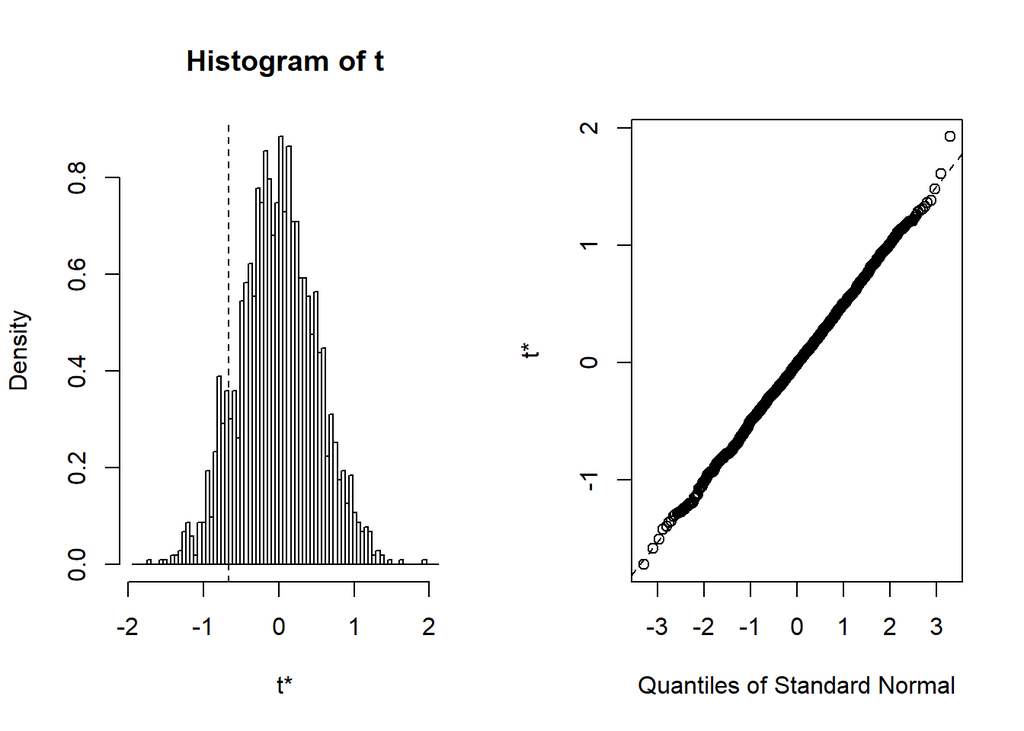

```r
# filtrando o grupo A
grupoA <- buscas %>%
            filter(group == "a")

# calcular o tamanho da amostra
amostraSize <- grupoA %>%
                    summarise(tamanho = n()) %>%
                    pull(tamanho)

funcao_taxa <- function(dados, indices) {

    dados <- dados %>%
        slice(indices)

    # primeira metade
    amostra1 <- dados %>%
                slice(1 : (amostraSize/2)) %>%
                mutate(grupo = "Primeira")

    # segunda metade
    amostra2 <- dados %>%
                slice(amostraSize/2 + 1: amostraSize) %>%
                mutate(grupo = "Segunda")

    nova_amostra <- bind_rows(amostra1, amostra2)

    # Repetir código a inferência anterior
    mediaTC <- nova_amostra %>%
            group_by(grupo, day) %>%
            summarise(clicks = sum(num_clicks), n = n(), taxa = (clicks/n)*100) %>%
            summarise(media = mean(taxa)) %>%
            pull(media)

    return(mediaTC[1] - mediaTC[2])
}

res.boot <- boot(data = grupoA,
                 statistic = funcao_taxa,
                 R = 2000)
plot(res.boot)
```

```r
boot.ci(boot.out = res.boot, conf = 0.95, type = "basic")
```

```
## BOOTSTRAP CONFIDENCE INTERVAL CALCULATIONS
## Based on 2000 bootstrap replicates
##
## CALL :
## boot.ci(boot.out = res.boot, conf = 0.95, type = "basic")
##
## Intervals :
## Level      Basic
## 95%   (-2.3209, -0.3324 )
## Calculations and Intervals on Original Scale
```

## 4. Pergunta 2: Quais resultados as pessoas tendem a tentar primeiro? Como isso muda no dia-a-dia?

Para essa pergunta estamos interessaods e buscas com resultados e que posuem o indice do primeiro click identificado. Resultados com resultados igual a 0 ou sem indice do primeiro click foram removidas. A inferência nesse caso será o intervalo de confiança para a média do first_click.

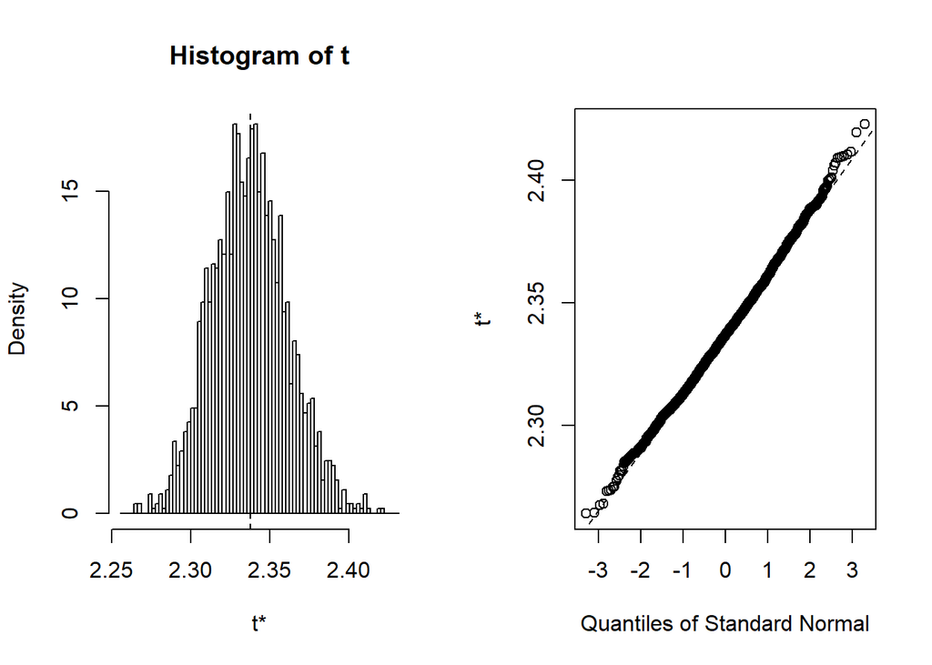

```r
buscas_com_resultado <- buscas %>%
    filter(results > 0, !is.na(first_click))

primeiroClique <- function(dados, indices) {
    media <- dados %>%
            slice(indices) %>%
            pull(first_click) %>%
            mean()

    return(media)
}

res.boot <- boot(data = buscas_com_resultado,
                 statistic = primeiroClique,
                 R = 2000)
plot(res.boot)
```

```r
boot.ci(boot.out = res.boot, conf = 0.95, type = "basic")
```

```
## BOOTSTRAP CONFIDENCE INTERVAL CALCULATIONS
## Based on 2000 bootstrap replicates
##
## CALL :
## boot.ci(boot.out = res.boot, conf = 0.95, type = "basic")
##
## Intervals :
## Level      Basic
## 95%   ( 2.289,  2.384 )
## Calculations and Intervals on Original Scale
```

Podemos inferir com 95% de confiança que as pessoas tendem a tentar primeiro, em média, nos resultados cujo indice está entre 2.291 e 2.382, ou seja, as pessoas tendem a tentar primeiro os primeiros resultados. A segunda questão relacionada a variação desse comportamento do longo do dia-a-dia.

[figure not shown]

```r
buscas_com_resultado <- buscas %>%
    filter(results > 0, !is.na(first_click))

buscas_com_resultado <- mutate(buscas_com_resultado, dia = strftime(day, '%A'))

domingo <- buscas_com_resultado %>%
                    filter(dia == "domingo")
segunda <- buscas_com_resultado %>%
                    filter(dia == "segunda-feira")
terca <- buscas_com_resultado %>%
                    filter(dia == "terça-feira")
quarta <- buscas_com_resultado %>%
                    filter(dia == "quarta-feira")
quinta <- buscas_com_resultado %>%
                    filter(dia == "quinta-feira")
sexta <- buscas_com_resultado %>%
                    filter(dia == "sexta-feira")
sabado <- buscas_com_resultado %>%
                    filter(dia == "sábado")

primeiroClique <- function(dados, indices) {
    media <- dados %>%
            slice(indices) %>%
            pull(first_click) %>%
            mean()

    return(media)
  }

distribuicaoF <- function(amostra) {
    distribuicao <- boot(data = amostra,
                 statistic = primeiroClique,
                 R = 2000)

    return(distribuicao)
}


distribuicao_domingo <- distribuicaoF(domingo)
distribuicao_segunda <- distribuicaoF(segunda)
distribuicao_terca <- distribuicaoF(terca)
distribuicao_quarta <- distribuicaoF(quarta)
distribuicao_quinta <- distribuicaoF(quinta)
distribuicao_sexta <- distribuicaoF(sexta)
distribuicao_sabado <- distribuicaoF(sabado)


ciDomingo = boot.ci(boot.out = distribuicao_domingo, conf = 0.95, type = "basic")
ciSegunda = boot.ci(boot.out = distribuicao_segunda, conf = 0.95, type = "basic")
ciTerca = boot.ci(boot.out = distribuicao_terca, conf = 0.95, type = "basic")
ciQuarta = boot.ci(boot.out = distribuicao_quarta, conf = 0.95, type = "basic")
ciQuinta = boot.ci(boot.out = distribuicao_quinta, conf = 0.95, type = "basic")
ciSexta = boot.ci(boot.out = distribuicao_sexta, conf = 0.95, type = "basic")
ciSabado = boot.ci(boot.out = distribuicao_sabado, conf = 0.95, type = "basic")

df = data.frame(rbind(ciDomingo,
                      ciSegunda,
                      ciTerca,
                      ciQuarta,
                      ciQuinta,
                      ciSexta,
                      ciSabado))
df$diaDaSemana = row.names(df)

df %>%
  ggplot(aes(x = diaDaSemana, ymin = substr(df$basic, 25, 28), ymax = substr(df$basic, 43, 46))) +
  geom_errorbar(width = .2)
```

## 5. Pergunta 3: Qual é a taxa de resultados zero no geral? Como isso varia entre os grupos?

Nesse momento estamos interessados em resultados zero, e inferir a taxa desses resultados na população. Em seguida iremos comparar a taxa nos grupos, semelhantemente ao que foi feito com o número de clicks. O gráfico a seguir mostra que com um intervalo de confiança de 95%, a taxa de resultados zero está entre 18,28% e 18,68%.

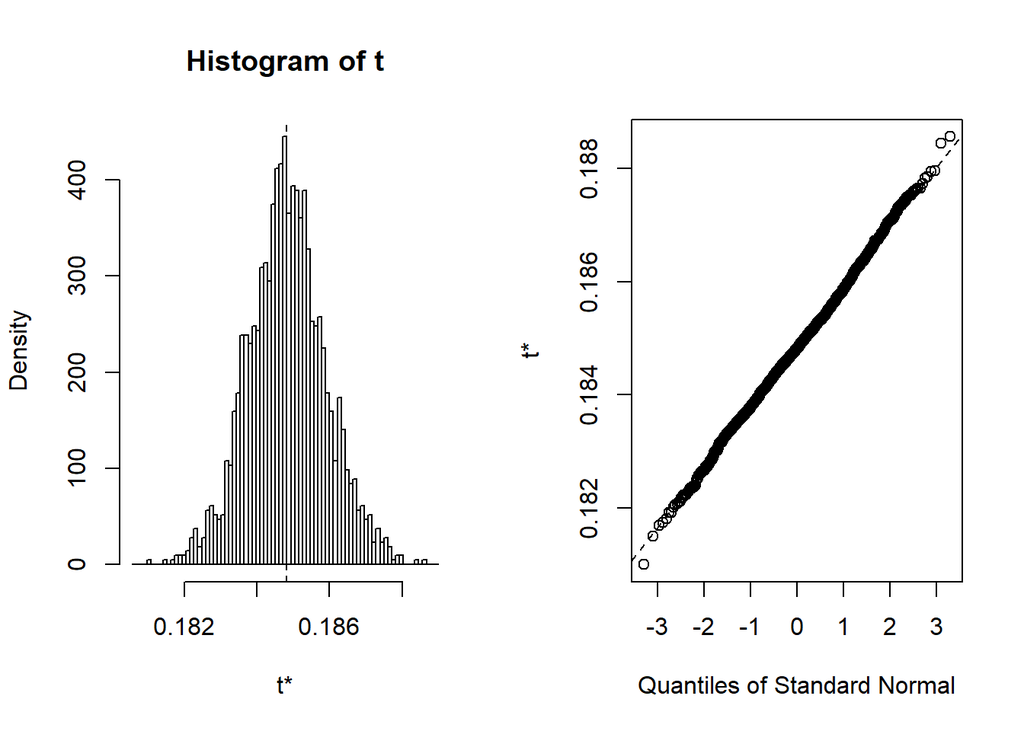

```r
amostra <- buscas

calcula_taxa_resultados <- function(dados, indices) {
    dados <- dados %>%
            slice(indices)

    total_sem_resultado <- dados %>%
                            filter(results == 0) %>%
                            summarise(total_buscas_vazias = n()) %>%
                            pull(total_buscas_vazias)

    total_de_buscas <- dados %>%
                        summarise(total_buscas = n()) %>%
                        pull(total_buscas)

    taxa_buscas_sem_resultado <- total_sem_resultado / total_de_buscas

    return(taxa_buscas_sem_resultado)
}

res.boot <- boot(data = amostra,
                 statistic = calcula_taxa_resultados,
                 R = 2000)

plot(res.boot)
```

```r
boot.ci(boot.out = res.boot, conf = 0.95, type = "basic")
```

```
## BOOTSTRAP CONFIDENCE INTERVAL CALCULATIONS
## Based on 2000 bootstrap replicates
##
## CALL :
## boot.ci(boot.out = res.boot, conf = 0.95, type = "basic")
##
## Intervals :
## Level      Basic
## 95%   ( 0.1826,  0.1869 )
## Calculations and Intervals on Original Scale
```

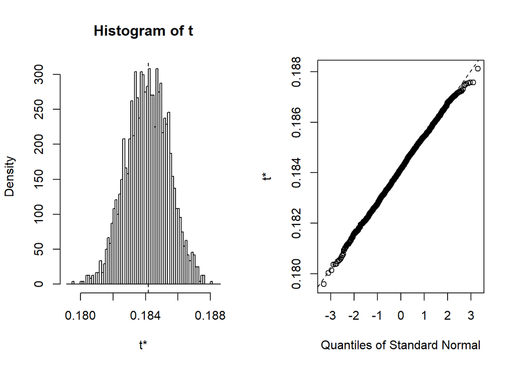

```r
amostra <- buscas

calcula_taxa_resultados <- function(dados, indices) {
    dados <- dados %>%
            slice(indices)

    buscas_sem_resultado <- dados %>%
                            filter(results == 0) %>%
                            group_by(group) %>%
                            summarise(total_buscas_vazias = n()) %>%
                            pull(total_buscas_vazias)

    total_de_buscas <- dados %>%
                        group_by(group) %>%
                        summarise(total_buscas = n()) %>%
                        pull(total_buscas)

    taxa_buscas_sem_resultado <- (buscas_sem_resultado[1] / total_de_buscas[1])
                                    - (buscas_sem_resultado[2] / total_de_buscas[2])

    return(taxa_buscas_sem_resultado)

}

res.boot <- boot(data = amostra,
                 statistic = calcula_taxa_resultados,
                 R = 2000)
plot(res.boot)
```

```r
boot.ci(boot.out = res.boot, conf = 0.95, type = "basic")
```

```
## BOOTSTRAP CONFIDENCE INTERVAL CALCULATIONS
## Based on 2000 bootstrap replicates
##
## CALL :
## boot.ci(boot.out = res.boot, conf = 0.95, type = "basic")
##
## Intervals :
## Level      Basic
## 95%   ( 0.1817,  0.1867 )
## Calculations and Intervals on Original Scale
```

## 6. Conclusões

Esse relatório abordou as mesmas questões do relatório descritivo, porém considerando os valores como amostra e inferindo valores para a população. Utilizou-se a técnica de intervalos de confiança e bootstrap.